# Modeling the Impact: When Data Hits Hard

### LASSO

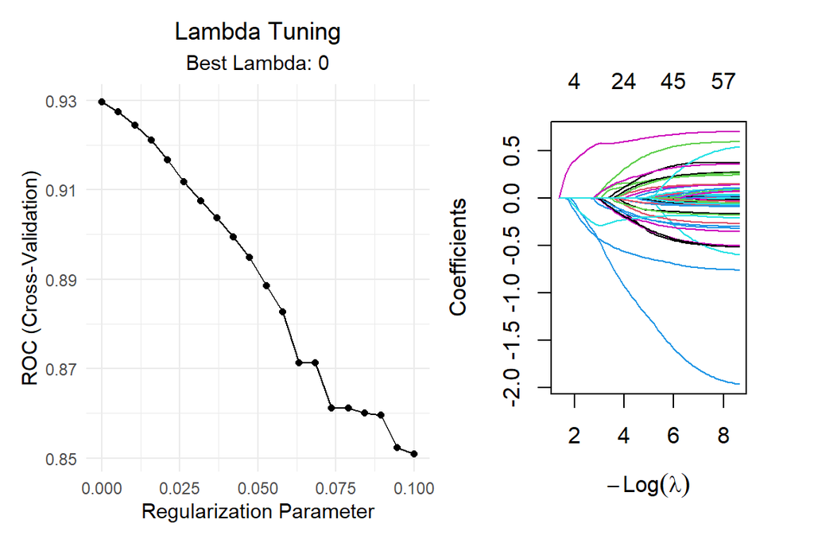

```r
# Define Grid for Lambda (Regularization Strength)
lasso_grid <- expand.grid(alpha = 1, lambda = seq(0.0001, 0.1, length = 20))

fit_lasso_binary <- train(crash_rec_binary, data = data_train_binary,
                   method = "glmnet",
                   trControl = ctrl_binary,
                   tuneGrid = lasso_grid,
                   metric = "ROC",
                   family = "binomial")
# Lasso Tuning Plot
p1 <- ggplot(fit_lasso_binary) +
      labs(title = "Lambda Tuning",
           subtitle = paste("Best Lambda:", round((fit_lasso_binary$bestTune$lambda), 3))) +
      theme_minimal() +
  theme(plot.subtitle = element_text(hjust = 0.5),
        plot.title = element_text(hjust = 0.5))

# Coefficient Path plot
p2 <- wrap_elements(full = ~{
  mod <- fit_lasso_binary$finalModel
  plot(mod, xvar = "lambda", label = TRUE)
  l_val <- log(fit_lasso_binary$bestTune$lambda)
  abline(v = l_val, col = "red", lty = 2, lwd = 2)
})

p1 + p2
```

```r
# --- Predictions ---
pred_class_lasso_binary <- predict(fit_lasso_binary, newdata = data_test_binary)

# --- Confusion Matrix & Heatmap ---
cm_lasso_binary <- confusionMatrix(pred_class_lasso_binary, data_test_binary$INJ_SEV,
                                   positive = "Fatal")

# See how many variables are kept/dropped
lasso_coefs_binary <- as.matrix(coef(fit_lasso_binary$finalModel, s = fit_lasso_binary$bestTune$lambda))

is_dropped <- lasso_coefs_binary[, 1] == 0

dropped_globally <- rownames(lasso_coefs_binary)[is_dropped]
dropped_globally <- dropped_globally[dropped_globally != "(Intercept)"]

kept_globally <- rownames(lasso_coefs_binary)[!is_dropped]
kept_globally <- kept_globally[kept_globally != "(Intercept)"]

# --- Results Summary ---
cat("--- LASSO GLOBAL FEATURE SELECTION (BINARY) ---\n")
```

```
--- LASSO GLOBAL FEATURE SELECTION (BINARY) ---
```

```r
cat("Total Variables Provided: ", nrow(lasso_coefs_binary) - 1, "\n")
```

```
Total Variables Provided:  60
```

```r
cat("Variables Kept:           ", length(kept_globally), "\n")
```

```
Variables Kept:            59
```

```r
cat("Variables Dropped:        ", length(dropped_globally), "\n\n")
```

```
Variables Dropped:         1
```

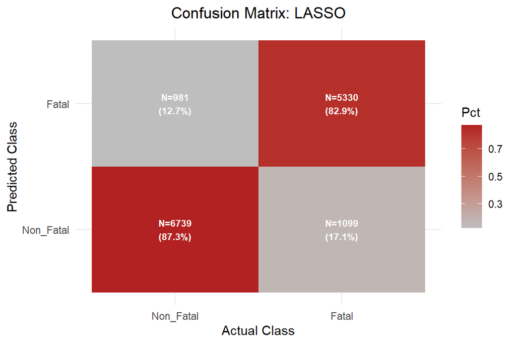

```r
# confusion matrix
plot_heatmap(data_test_binary$INJ_SEV, pred_class_lasso_binary, "LASSO")
```

```r
# Store ROC
pred_prob_lasso_binary <- predict(fit_lasso_binary, newdata = data_test_binary, type = "prob")
roc_lasso <- roc(data_test_binary$INJ_SEV, pred_prob_lasso_binary$Fatal)
```

### Ridge

Ridge regression delivers comparable performance to lasso, with balanced sensitivity across fatal and non-fatal outcomes. By retaining correlated predictors, ridge aggregates small effects that contribute to fatal risk, leading to stable recall without excessive false positives. As in the multiclass case, differences between linear models remain modest, but the clearer binary outcome allows their behavior to be interpreted more directly in terms of sensitivity and specificity.

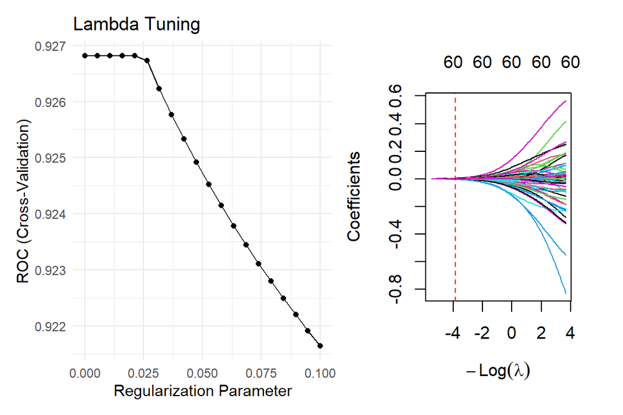

```r
# Define Grid for Lambda
ridge_grid <- expand.grid(alpha = 0, lambda = seq(0.0001, 0.1, length = 20))

fit_ridge_binary <- train(crash_rec_binary,
                          data = data_train_binary,
                   method = "glmnet",
                   trControl = ctrl_binary,
                   tuneGrid = ridge_grid,
                   metric = "ROC",
                   family = "binomial")

# 1. Optimal Lambda Path
p1 <- ggplot(fit_ridge_binary) +
      labs(title = "Lambda Tuning") +
      theme_minimal()

# 2. Coefficient Path plot
p2 <- wrap_elements(full = ~{
  plot(fit_ridge_binary$finalModel, xvar = "lambda", label = TRUE)
  # Add a vertical line for the optimal lambda
  abline(v = log(fit_ridge_binary$bestTune$lambda), col = "red", lty = 2)
})
p1 + p2
```

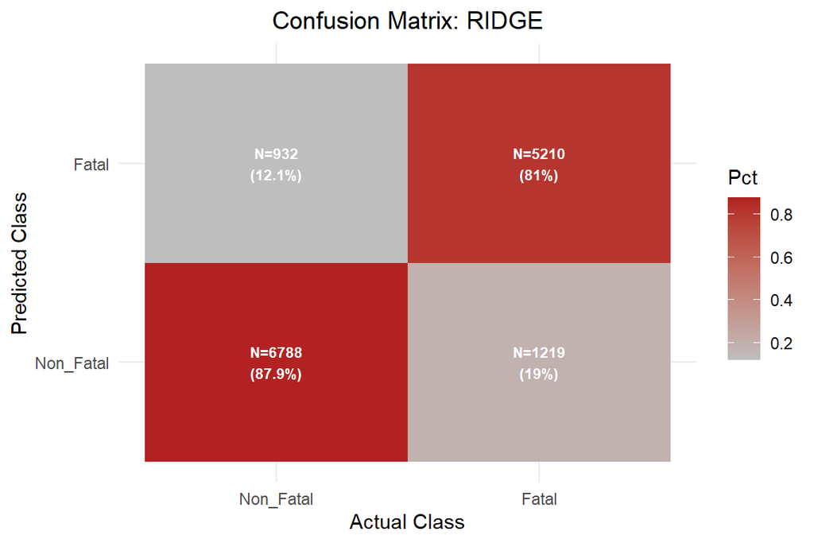

```r
# --- Predictions ---
pred_class_ridge_binary <- predict(fit_ridge_binary, newdata = data_test_binary)

# --- Confusion Matrix & Heatmap ---
cm_ridge_binary <- confusionMatrix(pred_class_ridge_binary, data_test_binary$INJ_SEV,
                                   positive = "Fatal")

plot_heatmap(data_test_binary$INJ_SEV, pred_class_ridge_binary, "RIDGE")
```

```r
# Store ROC
pred_prob_ridge_binary <- predict(fit_ridge_binary, newdata = data_test_binary, type = "prob")
roc_ridge <- roc(data_test_binary$INJ_SEV, pred_prob_ridge_binary$Fatal)
```

### kNN

kNN shows improved performance compared to its multiclass results but remains weaker than linear and tree-based models. While sensitivity for non-fatal crashes increases, the model still exhibits higher false negative rates for fatal outcomes, indicating limited ability to reliably detect death cases. This mirrors the multiclass setting, where local similarity struggled to separate overlapping injury categories, and suggests that distance-based methods remain sensitive to noise in high-dimensional feature space.

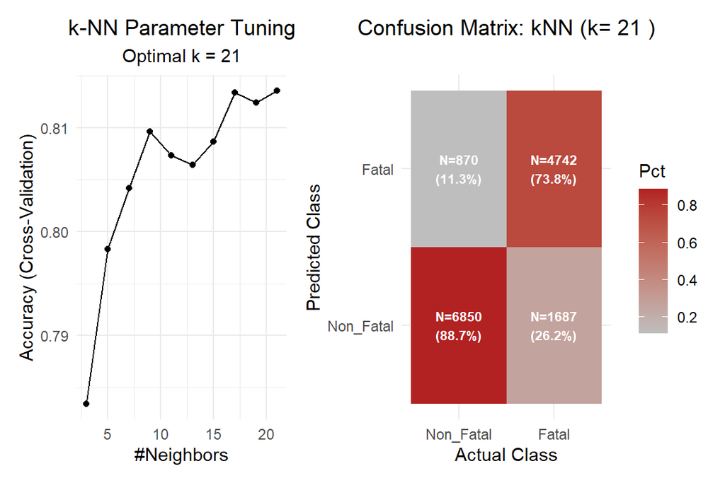

```r
# Define Grid for k
knn_grid <- expand.grid(k = seq(3, 21, by = 2))

fit_knn_binary <- train(crash_rec_binary,
                        data = data_train_binary_small,
                        method = "knn",
                        trControl = ctrl_binary_small,
                        metric = "ROC",
                        tuneGrid = knn_grid)

# --- Predictions ---
pred_class_knn_binary <- predict(fit_knn_binary, newdata = data_test_binary)

# --- Confusion Matrix & Heatmap ---
cm_knn_binary <- confusionMatrix(pred_class_knn_binary, data_test_binary$INJ_SEV,
                                 positive = "Fatal")

# Plot k vs Accuracy
p1 <- ggplot(fit_knn_binary) +
      labs(title = "k-NN Parameter Tuning",
           subtitle = paste("Optimal k =", fit_knn$bestTune$k)) +
      theme_minimal() +
      theme(plot.subtitle = element_text(hjust = 0.5),
        plot.title = element_text(hjust = 0.5))
# Confusion Matrix
p2 <- plot_heatmap(data_test_binary$INJ_SEV, pred_class_knn_binary,
                   paste("kNN (k=", fit_knn_binary$bestTune$k, ")"))
p1 + p2
```

```r
# Store ROC
pred_prob_knn_binary <- predict(fit_knn_binary, newdata = data_test_binary, type = "prob")
roc_knn <- roc(data_test_binary$INJ_SEV, pred_prob_knn_binary$Fatal)
```

### Random Forests

The random forest benefits more clearly from the binary outcome formulation. Compared to the multiclass case, the model achieves improved sensitivity for fatal crashes, indicating better detection of high-risk scenarios. However, gains are partially offset by a modest increase in false positives, reflecting a trade-off between sensitivity and specificity. While nonlinear interactions contribute more meaningfully in the binary setting, overall improvements over regularized linear models remain moderate.

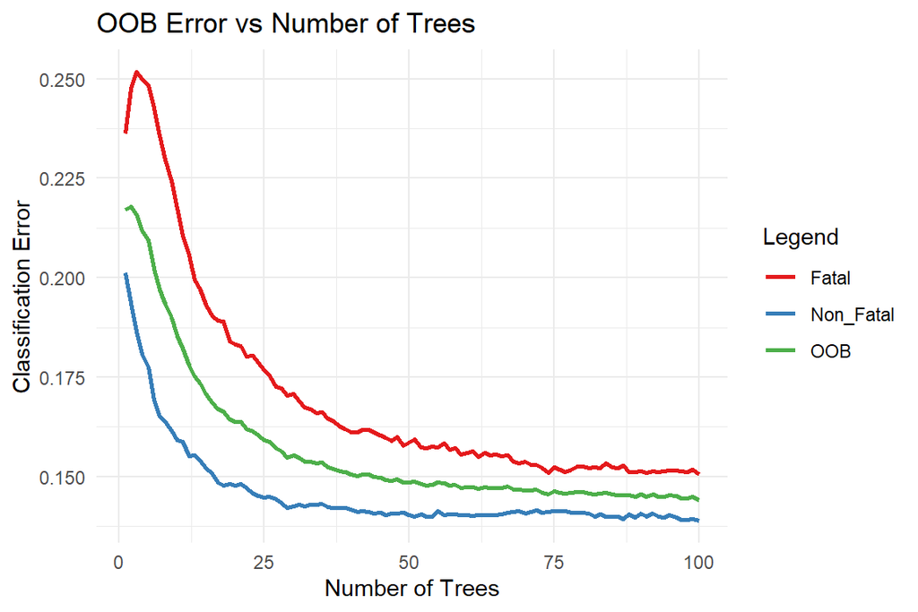

```r
# Note: 'mtry' is the main parameter to tune.
rf_grid <- expand.grid(mtry = c(2, 5, 10, floor(sqrt(ncol(data_train_binary)))))

fit_rf_binary <- train(crash_rec_binary, data = data_train_binary,
                method = "rf",
                trControl = ctrl_binary,
                tuneGrid = rf_grid,
                ntree = 100,
                metric = "ROC",
                importance = TRUE)


# --- Diagnostics ---
# 1. OOB Error Plot
oob_data_binary <- as.data.frame(fit_rf_binary$finalModel$err.rate) %>%
  mutate(Trees = row_number()) %>%
  pivot_longer(cols = -Trees, names_to = "Error_Type", values_to = "Error_Rate")

ggplot(oob_data_binary, aes(x = Trees, y = Error_Rate, color = Error_Type)) +
  geom_line(size = 1) +
  labs(
    title = "OOB Error vs Number of Trees",
    y = "Classification Error",
    x = "Number of Trees",
    color = "Legend"
  ) +
  theme_minimal() +
  scale_color_brewer(palette = "Set1")
```

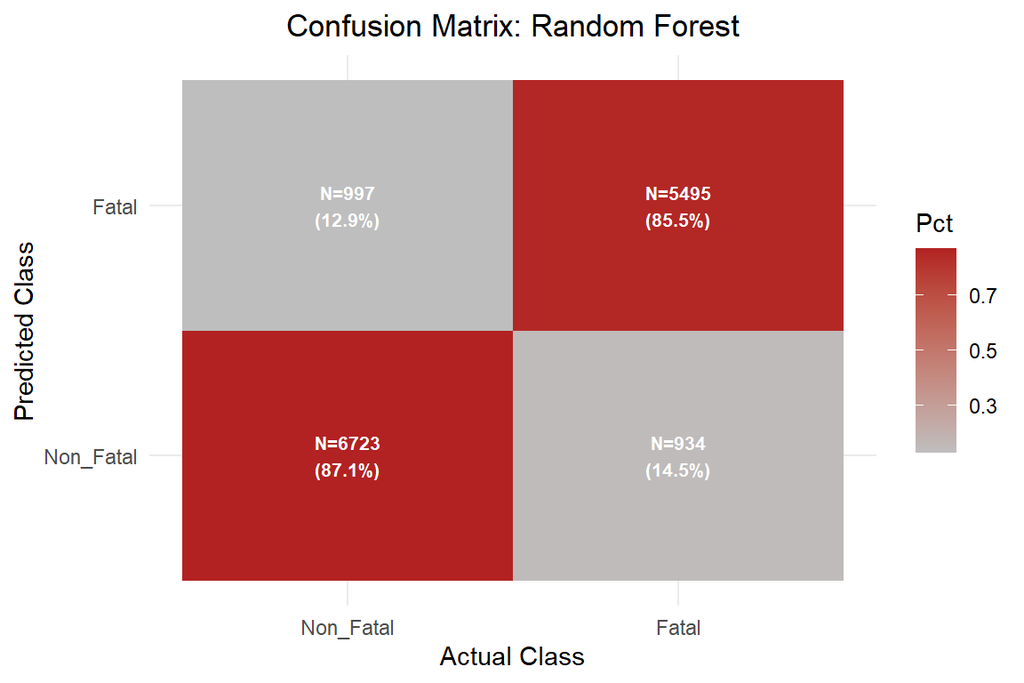

```r
# --- Predictions ---
pred_class_rf_binary <- predict(fit_rf_binary, newdata = data_test_binary)

# --- Confusion Matrix & Heatmap ---
cm_rf_binary <- confusionMatrix(pred_class_rf_binary, data_test_binary$INJ_SEV,
                                positive = "Fatal")

plot_heatmap(data_test_binary$INJ_SEV, pred_class_rf_binary, "Random Forest")
```

```r
# Store ROC
pred_prob_rf_binary <- predict(fit_rf_binary, newdata = data_test_binary, type = "prob")
roc_rf <- roc(data_test_binary$INJ_SEV, pred_prob_rf_binary$Fatal)
```

## Comparing Binary Performances

Across all models, the binary formulation enables clearer interpretation of performance in terms of sensitivity, specificity, and false positive/negative errors. Improvements relative to the multiclass setting are driven primarily by the removal of the ambiguous intermediate category, rather than by changes in model complexity. While direct metric comparisons are not appropriate, the binary results highlight how outcome definition influences achievable sensitivity for fatal crashes and overall classification stability.

```r
# Misclassification Rates (Accuracy):
model_comparison <- data.frame(
  Model = c("Logistic Regression", "Lasso", "Ridge", "k-NN", "Random Forest"),
  Accuracy = c(
    cm_logit$overall["Accuracy"],
    cm_lasso_binary$overall["Accuracy"],
    cm_ridge_binary$overall["Accuracy"],
    cm_knn_binary$overall["Accuracy"],
    cm_rf_binary$overall["Accuracy"]
  ),
  Balanced_Accuracy = c(
    cm_logit$byClass["Balanced Accuracy"],
    cm_lasso_binary$byClass["Balanced Accuracy"],
    cm_ridge_binary$byClass["Balanced Accuracy"],
    cm_knn_binary$byClass["Balanced Accuracy"],
    cm_rf_binary$byClass["Balanced Accuracy"]
  )
)

model_summary_table <- model_comparison %>%
  mutate(across(where(is.numeric), ~ round(., 3))) %>%
  arrange(desc(Accuracy))

print("--- Final Model Leaderboard (Misclassification Rate) ---")
```

```
[1] "--- Final Model Leaderboard (Misclassification Rate) ---"
```

```r
print(model_summary_table)
```

```
                Model Accuracy Balanced_Accuracy
1       Random Forest    0.864             0.863
2 Logistic Regression    0.853             0.851
3               Lasso    0.853             0.851
4               Ridge    0.848             0.845
5                k-NN    0.819             0.812
```

```r
# Gather all ROC objects into a list
roc_list <- list(
  Logistic      = roc_logit,
  Ridge         = roc_ridge,
  Lasso         = roc_lasso,
  kNN           = roc_knn,
  RandomForest  = roc_rf
)

# Extract AUC values
auc_values <- sapply(roc_list, function(x) as.numeric(auc(x)))

auc_table <- data.frame(
  Model = names(auc_values),
  AUC = round(auc_values, 4)
)

# Sort by AUC (Descending)
auc_table_sorted <- auc_table %>%
  arrange(desc(AUC))

print("--- Final Model Leaderboard (AUC) ---")
```

```
[1] "--- Final Model Leaderboard (AUC) ---"
```

```r
print(auc_table_sorted)
```

```
                    Model    AUC
RandomForest RandomForest 0.9372
Logistic         Logistic 0.9308
Lasso               Lasso 0.9308
Ridge               Ridge 0.9286
kNN                   kNN 0.9092
```

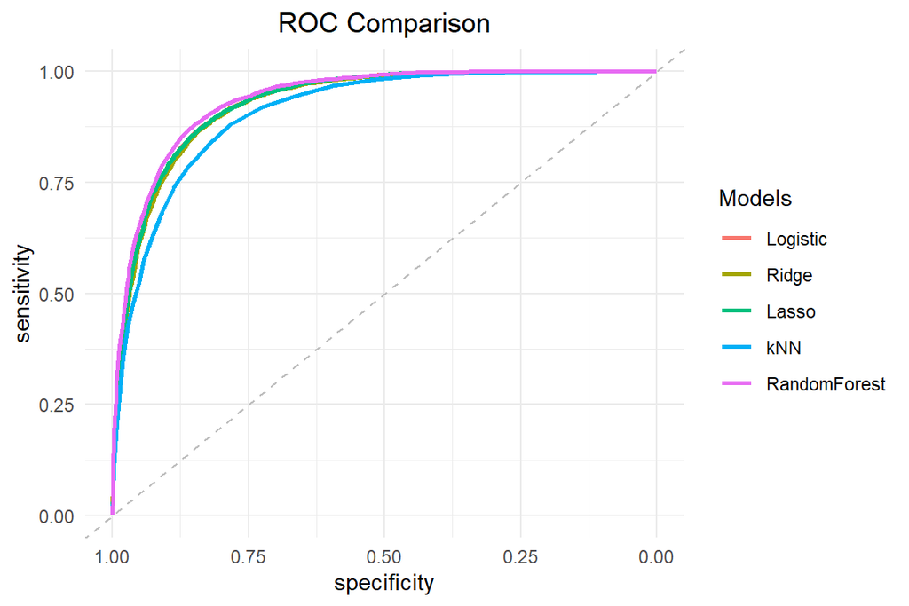

```r
ggroc(roc_list, size = 1) +
  geom_abline(slope = 1, intercept = 1, linetype = "dashed", color = "grey") +
  labs(title = "ROC Comparison",
       color = "Models")  +
  theme_minimal() +
  theme(plot.title = element_text(hjust = 0.5))
```

### Binary outcome conclusion

Reformulating injury severity as a binary outcome (fatal vs. non-fatal) leads to clearer and more stable model performance across all approaches. By removing the ambiguous intermediate injury category, the classification task becomes structurally simpler, allowing models to focus on separating extreme outcomes rather than ranking overlapping severity levels. While direct metric comparisons with the three-class setting are limited, the binary results demonstrate consistently improved discrimination and more meaningful differences between models. Importantly, the naturally closer balance between fatal and non-fatal outcomes yields better performance without the need for resampling. In contrast to earlier upsampling experiments, where gains for minority outcomes were offset by losses elsewhere, the binary formulation improves performance without introducing artificial noise or redistributing errors across classes. This suggests that the primary limitation in the multiclass setting was not class imbalance alone, but intrinsic overlap between injury severity categories. Overall, the binary analysis shows that clearer outcome definitions and natural class balance are more effective than resampling techniques in improving predictive performance. The results highlight how outcome formulation plays a central role in achievable model accuracy and interpretability, and demonstrate that simplifying the target variable can reveal stronger and more reliable predictive signal than adjusting class proportions through upsampling.

## 6.4 Variable Importance

The figure shows the most important predictors for lasso regression and random forest in the three-class injury severity setting. To allow comparison across models, variable importance scores were normalized within each model, benchmarking the most influential variable to one. This normalization makes relative importance comparable across fundamentally different modeling approaches.

Across both models, and consistently across alternative specifications (including undersampling and the binary outcome), a stable set of variables repeatedly emerges as influential, although their exact ranking varies. These variables can be grouped into a few key themes that appear decisive in determining crash severity.

Although these patterns suggest a coherent narrative linking vulnerability, protection, and crash dynamics to injury severity, interpretation is limited. Importance rankings vary across models due to differences in how predictors and interactions are handled, and reflect predictive relevance rather than causality.

The recurrence of similar variable groups across models nonetheless indicates robust underlying structure, while variation in rankings underscores that injury severity arises from multiple interacting factors rather than a single dominant driver.

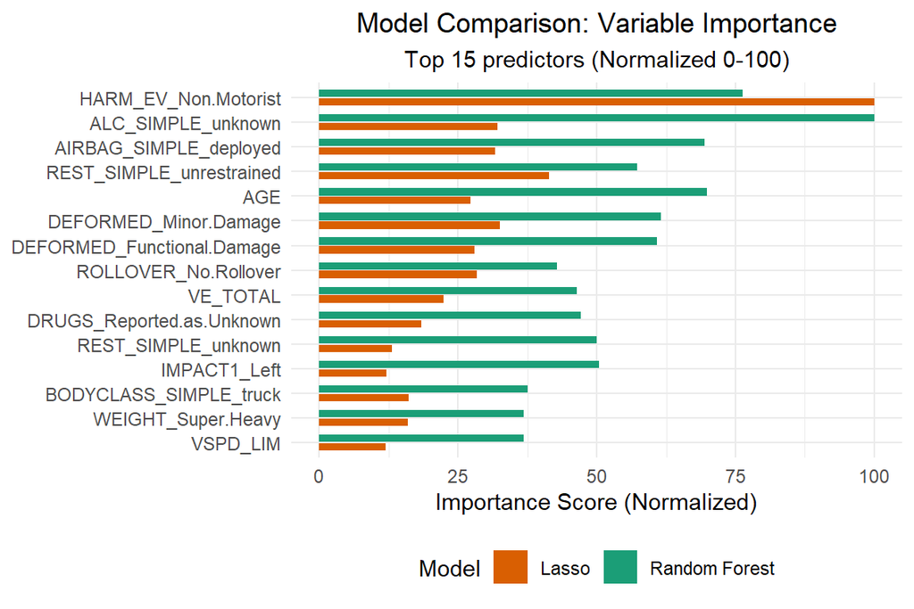

```r
lasso_coefs_raw <- coef(fit_lasso$finalModel, s = fit_lasso$bestTune$lambda)
lasso_vi <- do.call(rbind, lapply(names(lasso_coefs_raw), function(class_name) {
  data.frame(
    Variable = rownames(as.matrix(lasso_coefs_raw[[class_name]])),
    Importance = as.vector(as.matrix(lasso_coefs_raw[[class_name]])),
    Class = class_name
  )
})) %>%
  filter(Variable != "(Intercept)") %>%
  group_by(Variable) %>%
  summarize(Importance = mean(abs(Importance))) %>%
  mutate(Model = "Lasso")

# Random Forest Importance
rf_vi <- vi(fit_rf$finalModel) %>%
  rename(Importance = Importance) %>%
  mutate(Model = "Random Forest")

# Combine and Normalize (0-100 scale)
# We filter for the Top 20 variables from the Random Forest to keep the plot clean
top_vars <- rf_vi %>% arrange(desc(Importance)) %>% head(15) %>% pull(Variable)

combined_vi <- bind_rows(lasso_vi, rf_vi) %>%
  filter(Variable %in% top_vars) %>%
  group_by(Model) %>%
  mutate(Norm_Importance = (Importance / max(Importance)) * 100) %>%
  ungroup()

# Comparison Plot
ggplot(combined_vi, aes(x = Norm_Importance,
                        y = reorder(Variable, Norm_Importance),
                        fill = Model)) +
  geom_col(position = position_dodge(width = 0.7), width = 0.6) +
  scale_fill_manual(values = c("Random Forest" = "#1b9e77", "Lasso" = "#d95f02")) +
  labs(title = "Model Comparison: Variable Importance",
       subtitle = "Top 15 predictors (Normalized 0-100)",
       x = "Importance Score (Normalized)",
       y = NULL) +
  theme_minimal() +
  theme(legend.position = "bottom",
        plot.subtitle = element_text(hjust = 0.5),
        plot.title = element_text(hjust = 0.5))
```

# 7. Conclusions

This project analyzed injury severity in traffic crashes using multiple models, outcome formulations, and imbalance-handling strategies. Results show that outcome definition matters more than model complexity: in the multiclass setting, all models struggled to separate intermediate injury severity, while reformulating the task as fatal versus non-fatal led to clearer separation and more stable performance. Regularized linear models and random forests performed similarly, indicating that most predictive signal is additive and that increased model complexity offers limited gains. Attempts to address imbalance through upsampling did not improve performance, suggesting that class overlap rather than imbalance alone limits predictability.

Overall, the models achieve decent predictive performance, particularly in correctly identifying extreme outcomes; however, it is important to acknowledge several limitations. Many influential predictors, such as airbag deployment, vehicle deformation, fire, and rollover, are post-impact proxies that reflect crash severity rather than pre-crash risk, limiting causal insight. The data is U.S.-specific, reflecting particular driving behavior, vehicle fleets, and reporting practices, and no external validation was available. Overall, the findings highlight that while machine learning can capture meaningful structure in crash data, predictive performance is fundamentally bounded by outcome ambiguity, proxy variables, and data context.

Back to top